# Global Demographic Trend Analysis

Sejal Dhanta

2026-02-16

## **Introduction**

The World Bank is interested in understanding global demographic trends and the relationship between birth rates and internet usage across countries and income groups. This report aims to analyze patterns, highlight global disparities, and provide actionable insights that can inform policy and development strategies.

## **Objectives**

Explore the global demographic dataset for birth rates and internet usage.

Analyze the relationship between birth rate and internet penetration across countries.

Compare demographic trends across different income groups.

Provide insights and recommendations based on the analysis.

## **Data Import and Exploration**

### Load dataset

```r
getwd()
```

```
## [1] "C:/Users/SEJAL/Desktop"
```

```r
setwd('C:/Users/SEJAL/Desktop')
getwd()
```

```
## [1] "C:/Users/SEJAL/Desktop"
```

```r
stats=read.csv('DemographicData.csv')

stats=read.csv('DemographicData.csv')
```

## **Display dimensions and structure**

```r
cat("Number of rows:", nrow(stats), "\n")
```

```
## Number of rows: 195
```

```r
cat("Number of columns:", ncol(stats), "\n\n")
```

```
## Number of columns: 5
```

```r
str(stats)       # Structure of the dataset
```

```
## 'data.frame':    195 obs. of  5 variables:
##  $ Country.Name  : chr  "Aruba" "Afghanistan" "Angola" "Albania" ...
##  $ Country.Code  : chr  "ABW" "AFG" "AGO" "ALB" ...
##  $ Birth.rate    : num  10.2 35.3 46 12.9 11 ...
##  $ Internet.users: num  78.9 5.9 19.1 57.2 88 ...
##  $ Income.Group  : chr  "High income" "Low income" "Upper middle income" "Upper middle income" ...
```

```r
head(stats, 6)   # First 6 rows
```

```
##           Country.Name Country.Code Birth.rate Internet.users
## 1                Aruba          ABW     10.244           78.9
## 2          Afghanistan          AFG     35.253            5.9
## 3               Angola          AGO     45.985           19.1
## 4              Albania          ALB     12.877           57.2
## 5 United Arab Emirates          ARE     11.044           88.0
## 6            Argentina          ARG     17.716           59.9
##          Income.Group
## 1         High income
## 2          Low income
## 3 Upper middle income
## 4 Upper middle income
## 5         High income
## 6         High income
```

```r
tail(stats, 6)   # Last 6 rows
```

```
##         Country.Name Country.Code Birth.rate Internet.users        Income.Group
## 190            Samoa          WSM     26.172           15.3 Lower middle income
## 191      Yemen, Rep.          YEM     32.947           20.0 Lower middle income
## 192     South Africa          ZAF     20.850           46.5 Upper middle income
## 193 Congo, Dem. Rep.          COD     42.394            2.2          Low income
## 194           Zambia          ZMB     40.471           15.4 Lower middle income
## 195         Zimbabwe          ZWE     35.715           18.5          Low income
```

#3 **Convert Income.Group to factor**

```r
stats$Income.Group <- as.factor(stats$Income.Group)
levels(stats$Income.Group)
```

```
## [1] "High income"         "Low income"          "Lower middle income"
## [4] "Upper middle income"
```

## **Summary statistics**

```r
summary(stats)
```

```
##  Country.Name       Country.Code         Birth.rate    Internet.users
##  Length:195         Length:195         Min.   : 7.90   Min.   : 0.90
##  Class :character   Class :character   1st Qu.:12.12   1st Qu.:14.52
##  Mode  :character   Mode  :character   Median :19.68   Median :41.00
##                                        Mean   :21.47   Mean   :42.08
##                                        3rd Qu.:29.76   3rd Qu.:66.22
##                                        Max.   :49.66   Max.   :96.55
##               Income.Group
##  High income        :67
##  Low income         :30
##  Lower middle income:50
##  Upper middle income:48
##
##
```

## **Dataset contains**

Country.name – Name of the country

Country.Code – ISO code

Birth.rate – Births per 1000 people

Internet.users – Percentage of population using the internet

Income.Group – Country income category

## Check for missing values

```r
colSums(is.na(stats))
```

```
##   Country.Name   Country.Code     Birth.rate Internet.users   Income.Group
##              0              0              0              0              0
```

#3 Create a calculated column:

```r
Birth.rate <- stats$Birth.rate
stats$Birth.rate <- Birth.rate
```

```r
stats$MyCalc = stats$Birth.rate + stats$Internet.users
head(stats$MyCalc)
```

```
## [1] 89.144 41.153 65.085 70.077 99.044 77.616
```

## **Remove the temporary column**

```r
stats$MyCalc = NULL
```

```r
Birth.rate <- stats$Birth.rate
Internet.users <- stats$Internet.users
Income.Group <- stats$Income.Group
Country <- stats$Country.name
```

## **Filtering Data**

### Countries with Internet users < 2%

```r
low_internet <- stats[Internet.users < 2, ]
low_internet
```

```
##     Country.Name Country.Code Birth.rate Internet.users        Income.Group
## 12       Burundi          BDI     44.151            1.3          Low income
## 53       Eritrea          ERI     34.800            0.9          Low income
## 56      Ethiopia          ETH     32.925            1.9          Low income
## 65        Guinea          GIN     37.337            1.6          Low income
## 118      Myanmar          MMR     18.119            1.6 Lower middle income
## 128        Niger          NER     49.661            1.7          Low income
## 155 Sierra Leone          SLE     36.729            1.7          Low income
## 157      Somalia          SOM     43.891            1.5          Low income
## 173  Timor-Leste          TLS     35.755            1.1 Lower middle income
```

### Countries with Birth Rate > 40

```r
high_birth <- stats[Birth.rate > 40, ]
high_birth
```

```
##         Country.Name Country.Code Birth.rate Internet.users        Income.Group
## 3             Angola          AGO     45.985           19.1 Upper middle income
## 12           Burundi          BDI     44.151            1.3          Low income
## 15      Burkina Faso          BFA     40.551            9.1          Low income
## 66       Gambia, The          GMB     42.525           14.0          Low income
## 116             Mali          MLI     44.138            3.5          Low income
## 128            Niger          NER     49.661            1.7          Low income
## 129          Nigeria          NGA     40.045           38.0 Lower middle income
## 157          Somalia          SOM     43.891            1.5          Low income
## 168             Chad          TCD     45.745            2.3          Low income
## 179           Uganda          UGA     43.474           16.2          Low income
## 193 Congo, Dem. Rep.          COD     42.394            2.2          Low income
## 194           Zambia          ZMB     40.471           15.4 Lower middle income
```

### Countries with Birth Rate > 40 AND Internet users < 2%

```r
high_birth_low_internet <- stats[Birth.rate > 40 & Internet.users < 2, ]
high_birth_low_internet
```

```
##     Country.Name Country.Code Birth.rate Internet.users Income.Group
## 12       Burundi          BDI     44.151            1.3   Low income
## 128        Niger          NER     49.661            1.7   Low income
## 157      Somalia          SOM     43.891            1.5   Low income
```

### High income countries

```r
high_income <- stats[Income.Group == "High income", ]
high_income
```

```
##              Country.Name Country.Code Birth.rate Internet.users Income.Group
## 1                   Aruba          ABW     10.244       78.90000  High income
## 5    United Arab Emirates          ARE     11.044       88.00000  High income
## 6               Argentina          ARG     17.716       59.90000  High income
## 8     Antigua and Barbuda          ATG     16.447       63.40000  High income
## 9               Australia          AUS     13.200       83.00000  High income
## 10                Austria          AUT      9.400       80.61880  High income
## 13                Belgium          BEL     11.200       82.17020  High income
## 18                Bahrain          BHR     15.040       90.00004  High income
## 19           Bahamas, The          BHS     15.339       72.00000  High income
## 23                Bermuda          BMU     10.400       95.30000  High income
## 26               Barbados          BRB     12.188       73.00000  High income
## 27      Brunei Darussalam          BRN     16.405       64.50000  High income
## 31                 Canada          CAN     10.900       85.80000  High income
## 32            Switzerland          CHE     10.200       86.34000  High income
```

[output cut: 53 more lines]

### Specific country example

```r
india_data <- stats[Country == "India", ]
india_data
```

```
## [1] Country.Name   Country.Code   Birth.rate     Internet.users Income.Group
## <0 rows> (or 0-length row.names)
```

## **Scatterplot with ggplot2**

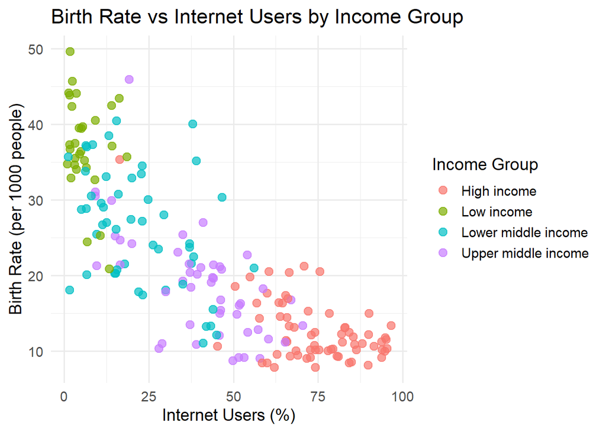

```r
library(ggplot2)

ggplot(stats, aes(x = Internet.users, y = Birth.rate, color = Income.Group)) +
  geom_point(size = 3, alpha = 0.7) +
  labs(title = "Birth Rate vs Internet Users by Income Group",
       x = "Internet Users (%)",
       y = "Birth Rate (per 1000 people)",
       color = "Income Group") +
  theme_minimal(base_size = 14)
```

## **Insights**

Countries with very few internet users usually have higher birth rates.

Countries with lots of internet users (high-income) usually have fewer babies born.

Low-income countries often have high birth rates and low internet usage.

Middle-income countries are mixed; some have high birth rates, some low.

There is a negative correlation: more internet → fewer babies.

Technology and education influence population trends.

Policy makers can plan education & internet programs to balance population growth.

## **Conclusion and Learnings**

### Conclusion

- The analysis shows a **strong negative relationship** between **Internet Usage** and **Birth Rate** globally.
- **High-income countries** typically have **low birth rates** and **high internet penetration**, reflecting advanced technological adoption and education.
- **Low-income countries** often have **high birth rates** and **low internet usage**, highlighting developmental disparities.
- **Middle-income countries** exhibit mixed patterns, indicating transitional demographic stages.
- This analysis emphasizes that **technology, education, and income levels** are key factors influencing population growth.

### Learnings

1. **Data Exploration Matters:** Creating separate variables (`Birth.rate`, `Internet.users`, `Income.Group`) makes analysis easier and clearer.
2. **Filtering with Base R:** Even without dplyr, you can filter and subset data effectively using `stats[condition, ]`.
3. **Visual Patterns Tell Stories:** Scatterplots allow you to **see trends and correlations** quickly, such as the inverse relationship between birth rate and internet usage.
4. **Income Groups Show Differences:** Categorizing countries by income group uncovers **distinct global demographic patterns**.
5. **Actionable Insights:** Increasing **internet access and education** may help manage population growth and support sustainable development.
6. **Professional Reporting Skills:** Presenting data with **plots, tables, and clear explanations** improves communication to stakeholders, even if you don’t use advanced libraries.
7. **Reproducible Workflows:** Keeping all calculations, filters, and plots in one structured script ensures **repeatable and reliable results**.